# Le rôle de la SAU à Muri et Affoltern

Chiara Coppa

10/13/2022

## Analyse exploratoire et échantillonage

Tout d’abord, pour effectuer une analyse exploratoire, il faut charger les données. On commence avec les données de la surface agricole utile pour les communes des districts de Muri et d’Affoltern. Je vais utiliser les données des deux communes ensemble pour avoir une quantité significative de données (33 communes). Je vais aussi donner un nom au tableau des données pour le retrouver plus facilement.

```r
com_muri_aff = read.delim('Donnees/Communes_Muri_Aff_2016_17_SA.tsv')
```

Avant de calculer des statistiques descriptives, on va calculer l’indicateur du pourcentage de surface agricole pour les communes des deux districts.

```r
com_muri_aff$pourcentage_SAU = ((com_muri_aff$Surfaces_agricoles_2016_17)/(com_muri_aff$Surface))*100
```

À partir de ça, on peut calculer des statistiques descriptives de nos données.

### Au niveaux des districts

On commence par la surface totale agricole des deux districts:

```r
somme_SAU = sum(com_muri_aff$Surfaces_agricoles_2016_17)
somme_SAU
```

```
## [1] 15187
```

En totale, les deux districts possèdent 15’187 ha de surface agricole qui équivaut à 151,87 km2.

Si on calcule le pourcentage:

```r
somme_surface = sum(com_muri_aff$Surface)
somme_surface
```

```
## [1] 25198
```

```r
pourcentage_SAU_tot = (somme_SAU/somme_surface)*100
pourcentage_SAU_tot
```

```
## [1] 60.27066
```

On a que le 60,3% de la surface est couverte de terrains agricoles.

### Au niveaux des communes

Si on calcule le maximum, le minimum et la moyenne des différentes communes, on trouve les valeurs suivantes:

```r
max_pour_SAU = max(com_muri_aff$pourcentage_SAU)
max_pour_SAU
```

```
## [1] 79.26829
```

```r
min_pour_SAU = min(com_muri_aff$pourcentage_SAU)
min_pour_SAU
```

```
## [1] 34.21751
```

```r
moy_muri_aff = mean(com_muri_aff$pourcentage_SAU)
moy_muri_aff
```

```
## [1] 60.55326
```

```r
moy_muri_aff_valeur = mean(com_muri_aff$Surfaces_agricoles_2016_17)
moy_muri_aff_valeur
```

```
## [1] 460.2121
```

Le pourcentage maximum de couverture agricole est de 79.3% pour la commune de Geltwil, dans le district de Muri, tandis que le pourcentage minimum est de 34,2% pour la commune de Wettswil am Albis, dans le district d’Affoltern. En moyenne, la surface agricole des communes de chaque district couvre environ le 60% de la surface, qu’en chiffres représente environ 460 ha (4,6 km2). Ces valeurs montrent la ruralité des deux districts, vue que, en moyenne, plus de la moitié des territoires des communes sont couverts par des surfaces agricoles.

```r
ecart = sd(com_muri_aff$pourcentage_SAU)
ecart
```

```
## [1] 10.83843
```

L’écart-type permet de mesurer la dispersion des données par rapport à la moyenne. Dans ce cas, on a une valeur de 10,8% qui n’est pas trop élevé pour nos données. Cela signifie que mes données sont assez proches de la moyenne.

La médiane est la suivante:

```r
mediane_SAU = median(com_muri_aff$pourcentage_SAU)
mediane_SAU
```

```
## [1] 64.26146
```

La médiane est plus élevée que la moyenne et elle vaut 64,3%. Pour mieux comprendre la différence entre ces deux valeurs, on réalise un histogramme de distribution des pourcentages de surface agricole utile.

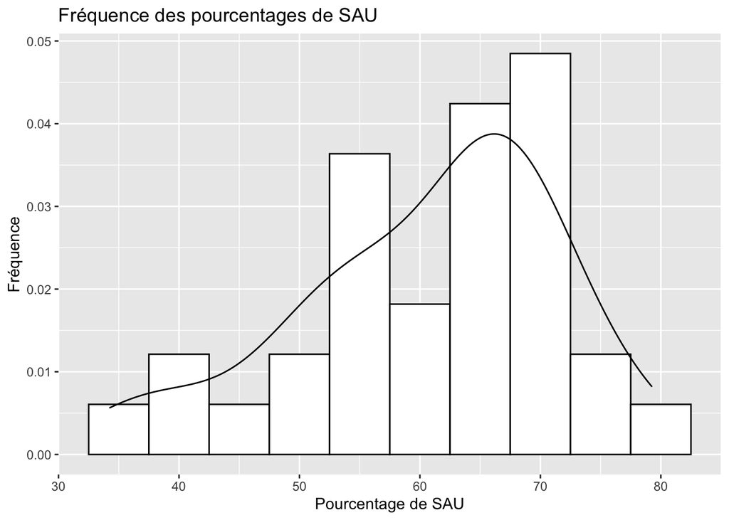

```r
library(ggplot2)
ggplot(com_muri_aff, aes(x=pourcentage_SAU)) +
 geom_histogram(aes(y=..density..),  binwidth = 5, colour="black", fill="white")+
 geom_density(alpha=.2) +
labs(title="Fréquence des pourcentages de SAU",x="Pourcentage de SAU", y = "Fréquence")
```

Grâce aussi au graphique, on peut dire que la valeur de la médiane est plus élevée par rapport à la moyenne à cause d’une série de valeurs “faibles” qui font baisser la moyenne.

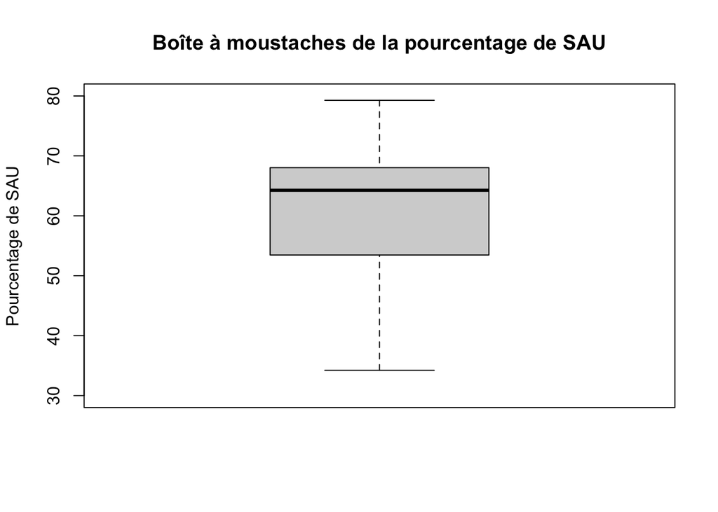

```r
boxplot(com_muri_aff$pourcentage_SAU, ylim = c(30,80), ylab = "Pourcentage de SAU", main = "Boîte à moustaches de la pourcentage de SAU")
```

Le boxplot montre la distribution des données de notre variable. La médiane ne se trouve pas au milieu de la boîte, cela signifie que nos valeurs ne sont pas symétriques (comme on voit dans l’histogramme). On n’y voit pas des valeurs extrêmes.

Nous pouvons réaliser un test de Kolmogorov-Smirnov pour évaluer si la variable de le pourcentage de surface agricole utile suit une loi normale. Les deux hypothèses que nous avons sont:

$H_0$: La variable suit une loi normale

$H_1$: La variable ne suit pas une loi normale

```r
ks.test(com_muri_aff$pourcentage_SAU, "pnorm", moy_muri_aff, ecart)
```

```
##
##  One-sample Kolmogorov-Smirnov test
##
## data:  com_muri_aff$pourcentage_SAU
## D = 0.14903, p-value = 0.4155
## alternative hypothesis: two-sided
```

Si on considère un seuil alfa de 5%, on a une *valeur p* (0,42) qui est plus élevée (0,42 > 0,05). Ceci est valide aussi pour un seuil alfa de 10%. À partir de ces valeurs, on ne peut pas rejeter l’hypothèse H0. On peut donc conclure que le pourcentage de surface agricole utile suit une loi normale.

## Comparaison de la moyenne pour un échantillon

Dans cette partie, on va effectuer un test de Student sur la variable de le pourcentage de surface agricole pour voir si la moyenne d’un échantillon correspond à la moyenne de l’ensemble de la population. Dans ce cas, on va analyser si la moyenne des communes pour les deux districts de Muri et Affoltern est la même que celle de la Suisse.

Tout d’abord, on charge les données pour toutes les communes de la Suisse:

```r
suisse = read.delim('Donnees/Surface_agricole_ch.tsv')
```

On calcule le pourcentage de surface agricole utile pour toute la Suisse et sa moyenne.

```r
suisse$pourcentage_SAU_ch = (suisse$Surface_agricole/suisse$Surface)*100

moy_ch = mean(suisse$pourcentage_SAU_ch)
moy_ch
```

```
## [1] 44.08014
```

```r
moy_muri_aff # rappel de la moyenne des deux districts
```

```
## [1] 60.55326
```

La moyenne est de 44% assez différente de la moyenne des deux districts (60,6%). Malgré cette grande différence, on effectue quand même un test de Student pour évaluer si la différence entre les deux moyennes est significative. On évalue donc les deux hypothèses suivantes:

$H_0$ = la moyenne des deux districts est égale à celle de la Suisse

$H_1$ = la moyenne des deux districts est différente de celle de la Suisse

```r
t.test(com_muri_aff$pourcentage_SAU, mu=moy_ch)
```

```
##
##  One Sample t-test
##
## data:  com_muri_aff$pourcentage_SAU
## t = 8.731, df = 32, p-value = 5.619e-10
## alternative hypothesis: true mean is not equal to 44.08014
## 95 percent confidence interval:
##  56.71011 64.39640
## sample estimates:
## mean of x
##  60.55326
```

Le résultat du test nous donne une *valeur p* d’ordre de grandeur e-10. En raison de cette faible valeur de p, on rejet $H_0$ et on accepte $H_1$, tel que prévu. La moyenne de surface agricole utile des deux communes est donc significativement différente de celle de la moyenne suisse.

## Comparaison de la moyenne pour deux échantillons (avec pondération)

Dans cette partie on va comparer les données des deux districts analysés jusqu’ici avec leurs respectifs cantons. Je vais faire une comparaison de la moyenne des deux districts par rapport au canton de Zurich et ensuite aussi par rapport au canton d’Argovie.

Tout d’abord, on peut charger les données pour les deux cantons:

```r
canton_zurich = read.delim('Donnees/Communes_Zurich_2016_17_SA.tsv')

canton_argovie = read.delim('Donnees/Communes_Argovie_2016_17_SA.tsv')
```

Premièrement on calcule nos variables, c’est-à-dire la pourcentage de surface agricole pour tous les communes du canton d’Argovie et de Zurich (séparément), leurs moyennes et écarts-types.

```r
canton_zurich$pourcentage_SA_zurich = (canton_zurich$Surfaces_agricoles_2016_17/canton_zurich$Surface)*100
canton_argovie$pourcentage_SA_argovie = (canton_argovie$Surfaces_agricoles_2016_17/canton_argovie$Surface)*100

moy_zurich = mean(canton_zurich$pourcentage_SA_zurich)
moy_argovie = mean(canton_argovie$pourcentage_SA_argovie)

ecart_zurich = sd(canton_zurich$pourcentage_SA_zurich)
ecart_argovie = sd(canton_argovie$pourcentage_SA_argovie)
```

## Test de Kolmogorov-Smirnov

On effectue un test de Kolmogorov-Smirnov sur les données des deux cantons pour voir si elles suivent une loi normale.

$H_0$: La variable suit une loi normale

$H_1$: La variable ne suit pas une loi normale

```r
ks.test(canton_zurich$pourcentage_SA_zurich, "pnorm", moy_zurich, ecart_zurich)
```

```
##
##  One-sample Kolmogorov-Smirnov test
##
## data:  canton_zurich$pourcentage_SA_zurich
## D = 0.048071, p-value = 0.8482
## alternative hypothesis: two-sided
```

```r
ks.test(canton_argovie$pourcentage_SA_argovie, "pnorm", moy_argovie, ecart_argovie)
```

```
##
##  One-sample Kolmogorov-Smirnov test
##
## data:  canton_argovie$pourcentage_SA_argovie
## D = 0.037599, p-value = 0.9279
## alternative hypothesis: two-sided
```

Les deux tests de Kolmogorov-Smirnov pour les cantons de Zurich et Argovie acceptent $H_0$ et rejettent $H_1$. Les données des deux cantons suivent donc des lois normales.

Afin de tenir compte de la pondération des deux districts par rapport aux deux cantons, j’effectue un bootstrap sur chaque région. Ensuite, je vais utiliser les tests de Student pour comparer les moyennes. Je peux utiliser le test de Student parce que mes valeurs suivent une loi normale (vérifiée avec les tests de Kolmogorov-Smirnov). Pour obtenir des résultats significatifs, le bootstrap et le test de Student sont répétés 10’000 fois.

D’abord, on va calculer le bootstrap pour les deux districts ensemble et le canton de Zurich et on effectue sur ces valeurs pondérées le test de Student. Les deux hypothèses qu’on va tester sont les suivantes:

$H_0$ = les moyennes des deux échantillons sont égales

$H_1$ = les moyennes des deux échantillons sont différentes

```r
pvalues = c()

for (i in 1:10000) {
  # Bootstrap pour les deux districts de Muri et Affoltern
  samp_idx_muri_aff = sample(
    x = seq_len(nrow(com_muri_aff)),
    size = nrow(com_muri_aff),
    replace = TRUE,
    prob = com_muri_aff$Surface)


  muri_aff_ech = com_muri_aff[samp_idx_muri_aff,]

  # Bootstrap pour le canton de Zurich
  samp_idx_zurich = sample(
    x = seq_len(nrow(canton_zurich)),
    size = nrow(canton_zurich),
    replace = TRUE,
    prob = canton_zurich$Surface)
  zurich_ech = canton_zurich[samp_idx_zurich,]

  # Test de student
  tt_1 = t.test(muri_aff_ech$pourcentage_SAU, zurich_ech$pourcentage_SA_zurich)

  pval = tt_1$p.value

  pvalues = c(pvalues, pval)
}

valeur_p_tt_1 = mean(pvalues)
valeur_p_tt_1
```

```
## [1] 2.090863e-07
```

La moyenne des 10’000 valeurs p est une valeur très petite, toujours d’ordre de grandeur de e-07. Peu importe le seuil alfa qu’on choisit, la *valeur p* est très petite. On va donc rejeter $H_0$ et accepter $H_1$. Les deux régions possèdent donc des moyennes qui sont significativement différentes entre eux. Les communes des deux districts de Muri et Affoltern ont donc des valeurs de surface agricole différentes par rapport au canton de Zurich. En regardant la moyenne des communes des cantons de Zurich, on peut déduire que les deux districts ont une quantité de surface agricole utile majeure par rapport au canton de Zurich en général.

```r
moy_zurich = mean(canton_zurich$pourcentage_SA_zurich)
moy_zurich
```

```
## [1] 43.40391
```

La même chose, on peut l’appliquer au canton d’Argovie:

```r
pvalues2 = c()

for (i in 1:10000) {
  # Bootstrap pour les districts de Muri et Affoltern
  samp_idx_muri_aff = sample(
    x = seq_len(nrow(com_muri_aff)),
    size = nrow(com_muri_aff),
    replace = TRUE,
    prob = com_muri_aff$Surface)

  muri_aff_ech = com_muri_aff[samp_idx_muri_aff,]

  # Bootstrap pour le canton d'Argovie
  samp_idx_argovie = sample(
    x = seq_len(nrow(canton_argovie)),
    size = nrow(canton_argovie),
    replace = TRUE,
    prob = canton_argovie$Surface)
  argovie_ech = canton_argovie[samp_idx_argovie,]

  # Test de student
  tt_2 = t.test(muri_aff_ech$pourcentage_SAU, argovie_ech$pourcentage_SA_argovie)

  pval2 = tt_2$p.value

  pvalues2 = c(pvalues2, pval2)
}

valeur_p_tt_2 = mean(pvalues2)
valeur_p_tt_2
```

```
## [1] 4.80305e-07
```

Dans ce cas, on a aussi que la *valeur p* est très petite, on peut donc rejeter $H_0$ et accepter $H_1$. Les moyennes des deux districts et du canton d’Argovie sont différentes. La moyenne du canton d’Argovie calculé en bas nous fait comprendre que les deux districts qu’on a analysés ont un nombre de surfaces agricoles, significativement majeur par rapport à la moyenne du canton Argovie.

```r
moy_argovie = mean(canton_argovie$pourcentage_SA_argovie)
moy_argovie
```

```
## [1] 43.60783
```

## Conclusion

Pour conclure, on peut reconsidérer quelques éléments qui sont ressortis dans cette analyse. Premièrement, le pourcentage de surface agricole utile est considérable pour les deux districts qu’on a analysés. En effet, plus de la moitié de la surface du territoire est couverte par la surface agricole utile. En comparant ces deux districts avec les cantons de Zurich et Argovie, on a démontré grâce aux tests statistiques que les valeurs de pourcentage de surface agricole sont significativement différentes des cantons. En regardant les moyennes, on a constaté que les districts possèdent une quantité majeure de SAU par rapport aux cantons. Ces deux districts ont été définis assez rurales selon la classification de l’OFS du 2012 (voir étude territoriale) et ils présentent des surfaces planes qui sont favorables à l’agriculture. En plus, ils sont situés dans le plateau, où on trouve presque la moitié des surfaces agricoles suisses. Les districts de Muri et Affoltern possèdent donc des caractéristiques particulières au niveau des surfaces agricoles utiles, en présentant une majeure exploitation agricole du territoire.

## Sources

Tous les données utilisées ont été téléchargées du site de l’Office fédérale de la statistique. Les données font partie de la *Statistique de la superficie 2013/18* (édition du 20.10.2021). Lien pour télécharger les données: https://www.bfs.admin.ch/asset/fr/19805706